# Bonus1: Parallel Algorithms

### Name: [Mei Xu]

## 0. You will do the following:

1. Read the lecture note: [click here](https://github.com/wangshusen/DeepLearning/blob/master/LectureNotes/Parallel/Parallel.pdf)
2. Implement federated averaging or decentralized optimization.
3. Plot the convergence curve. (The x-axis can be `number of epochs` or `number of communication`. You must make sure the label is correct.)
4. Convert the .IPYNB file to .HTML file.
   - The HTML file must contain **the code** and **the output after execution**.
5. Upload this .HTML file to your Google Drive, Dropbox, or your Github repo. (If it is submitted to Google Drive or Dropbox, you must make the file open-access.)
6. Submit the link to this .HTML file to Canvas.
   - Example: https://github.com/wangshusen/CS583-2020S/blob/master/homework/Bonus1/Bonus1.html

```python
!wget https://www.csie.ntu.edu.tw/~cjlin/libsvmtools/datasets/binary/diabetes
```

```
--2021-04-12 03:34:36--  https://www.csie.ntu.edu.tw/~cjlin/libsvmtools/datasets/binary/diabetes
Resolving www.csie.ntu.edu.tw (www.csie.ntu.edu.tw)... 140.112.30.26
Connecting to www.csie.ntu.edu.tw (www.csie.ntu.edu.tw)|140.112.30.26|:443... connected.
HTTP request sent, awaiting response... 200 OK
Length: 75503 (74K)
Saving to: ‘diabetes.26’

diabetes.26         100%[===================>]  73.73K   266KB/s    in 0.3s

2021-04-12 03:34:37 (266 KB/s) - ‘diabetes.26’ saved [75503/75503]
```

# 1. Data processing

- Download the Diabete dataset from https://www.csie.ntu.edu.tw/~cjlin/libsvmtools/datasets/binary/diabetes
- Load the data using sklearn.
- Preprocess the data.

## 1.1. Load the data

```python
from sklearn import datasets
import numpy

x_sparse, y = datasets.load_svmlight_file('diabetes')
x = x_sparse.todense()

print('Shape of x: ' + str(x.shape))
print('Shape of y: ' + str(y.shape))
```

```
Shape of x: (768, 8)
Shape of y: (768,)
```

## 1.2. Partition to training and test sets

```python
# partition the data to training and test sets
n = x.shape[0]
n_train = 640
n_test = n - n_train

rand_indices = numpy.random.permutation(n)
train_indices = rand_indices[0:n_train]
test_indices = rand_indices[n_train:n]

x_train = x[train_indices, :]
x_test = x[test_indices, :]
y_train = y[train_indices].reshape(n_train, 1)
y_test = y[test_indices].reshape(n_test, 1)

print('Shape of x_train: ' + str(x_train.shape))
print('Shape of x_test: ' + str(x_test.shape))
print('Shape of y_train: ' + str(y_train.shape))
print('Shape of y_test: ' + str(y_test.shape))
```

```
Shape of x_train: (640, 8)
Shape of x_test: (128, 8)
Shape of y_train: (640, 1)
Shape of y_test: (128, 1)
```

## 1.3. Feature scaling

Use the standardization to trainsform both training and test features

```python
# Standardization
import numpy

# calculate mu and sig using the training set
d = x_train.shape[1]
mu = numpy.mean(x_train, axis=0).reshape(1, d)
sig = numpy.std(x_train, axis=0).reshape(1, d)

# transform the training features
x_train = (x_train - mu) / (sig + 1E-6)

# transform the test features
x_test = (x_test - mu) / (sig + 1E-6)

print('test mean = ')
print(numpy.mean(x_test, axis=0))

print('test std = ')
print(numpy.std(x_test, axis=0))
```

```
test mean =
[[ 0.00787916 -0.10981395  0.03669789  0.03163742 -0.10822424  0.06639968
   0.04635186  0.08119892]]
test std =
[[0.9930996  1.10133894 0.76230988 0.93891747 0.76206145 0.81085727
  0.9517824  1.03385756]]
```

## 1.4. Add a dimension of all ones

```python
n_train, d = x_train.shape
x_train = numpy.concatenate((x_train, numpy.ones((n_train, 1))), axis=1)

n_test, d = x_test.shape
x_test = numpy.concatenate((x_test, numpy.ones((n_test, 1))), axis=1)

print('Shape of x_train: ' + str(x_train.shape))
print('Shape of x_test: ' + str(x_test.shape))
```

```
Shape of x_train: (640, 9)
Shape of x_test: (128, 9)
```

# 2. Federated Averaging Model

## 2.1. Worker Node

```python
class Worker:
  def __init__(self, x, y):
    self.x = x # s-by-d local feature matrix
    self.y = y # s-vy-1 local label matrix
    self.s = x.shape[0] # number of local samples
    self.d = x.shape[1] # number of features
    self.w = numpy.zeros((d, 1)) # d-by-1 model parameter vector

  # Set the model parameters to the latest
  def set_param(self, w):
    self.w = w

  # Compute the local lose
  def loss(self):
    yx = numpy.multiply(self.y, self.x) # s-by-d matrix
    yxw = numpy.dot(yx, self.w) # s-by-1 matrix
    vec1 = numpy.exp(-yxw) # s-by-1 matrix
    vec2 = numpy.log(1 + vec1) # s-by-1 matrix
    return numpy.sum(vec2) # loss function

  # Compute the local gradient - GD
  def gradient(self):
    yx = numpy.multiply(self.y, self.x) # s-by-d matrix
    yxw = numpy.dot(yx, self.w) # s-by-1 matrix
    vec1 = numpy.exp(yxw) # s-by-1 matrix
    vec2 = numpy.divide(yx, 1+vec1) # s-by-d matrix
    g = -numpy.sum(vec2, axis=0).reshape(self.d, 1) # d-by-1 matrix
    return g

  # Compute the local gradient - SGD
  def sgd_gradient(self, xi, yi, lam):
    yx = numpy.multiply(yi, xi)
    yxw = numpy.dot(yx, self.w)
    g = -yx.T / (1 + numpy.exp(yxw))
    return g

  # Update the local parameters using gradient descent
  # Args:
  #   alpha: learning rate
  def gd(self, alpha, lam, q):
    for _ in range(q):
      self.w -= alpha * (self.gradient() / self.s + lam * self.w)

  # Update the local parameters using SGD
  def sgd(self, alpha, lam, q):
    for _ in range(q):
      rand_indices = numpy.random.permutation(self.s)
      x_rand = self.x[rand_indices, :]
      y_rand = self.y[rand_indices]
      for i in range(self.s):
        xi = x_rand[i, :]
        yi = float(y_rand[i])
        g = self.sgd_gradient(xi, yi, lam)
        self.w -= alpha * (g + lam * self.w)
      alpha *= 0.9
```

## 2.2. Server

```python
class Server:
  def __init__(self, m, n, d):
    self.m = m # number of worker nodes
    self.n = n # number of training samples
    self.d = d # number of features
    self.w = numpy.zeros((d, 1)) # d-by-1 model parameter vector
    self.g = numpy.zeros((d, 1)) # d-by-1 gradient
    self.loss = 0
    self.obj = 0

  # Sum the local w and loss functions evaluated by the worker
  # Args:
  #   params: a list of d-by-1 vectors
  #   losses: a list of scalars
  def aggregate(self, params, losses):
    self.w = numpy.zeros((self.d, 1))
    self.loss = 0
    for k in range(self.m):
      self.w += params[k]
      self.loss += losses[k]

  # Update the model parameters
  def new_param(self):
      self.w = self.w / self.m

  # Broadcast the new parameter to workers
  def broadcast(self):
    return self.w

  # Compute the objective function  (sum of loss and regularization)
  def objective(self, lam):
    reg = lam / 2 * numpy.sum(self.w * self.w)
    self.obj = self.loss / self.n + reg
    return self.obj
```

## 2.3. Initialization

The following function create one server and a list of m workers. I partition the n samples to m parts and use each part to create one worker.

I use m = 4 workers and apply the function create server workers. The returned are server (an object) and workers (a list of objects).

```python
import math

# Create a server and m worker nodes

def create_server_workers(m, x, y):
  n, d = x.shape
  s = math.floor(n / m)
  server = Server(m, n, d)
  workers = []

  for i in range(m):
    indices = list(range(i*s, (i+1)*s))
    worker = Worker(x[indices, :], y[indices, :])
    workers.append(worker)

  return server, workers

m = 4 # number of worker nodes
server, workers = create_server_workers(m, x_train, y_train)
```

# 3. Performing Federated Averaging

## 3.1. GD with q = 1 & 8

```python
lam = 1E-6
alpha = 1e-1
max_epoch = 50

def Fagd(q):
  m = 4 # number of worker nodes
  server, workers = create_server_workers(m, x_train, y_train)
  objvals_gd = numpy.zeros(max_epoch)
  for t in range(max_epoch):
    # step1: broadcast server's parameter to workers
    w = server.broadcast()
    for worker in workers:
      worker.set_param(w)

    # step2: workers' local computation
    params = []
    losses = []
    for worker in workers:
      worker.gradient()
      worker.gd(alpha, lam, q)
      params.append(worker.w)
      l = worker.loss()
      losses.append(l)

    # step3: aggregate the workers' parameters
    server.aggregate(params, losses)

    # step4: server update  the model parameters
    server.new_param() # compute new w
    obj = server.objective(lam) # compute objective function
    objvals_gd[t] = obj
    print('Objective value at epoch t=' + str(t) + ' is ' + str(obj))
  return objvals_gd

objvals_gd1 = Fagd(1)
print('-' * 55)
objvals_gd8 = Fagd(8)
```

```
Objective value at epoch t=0 is 0.6637293400007788
Objective value at epoch t=1 is 0.6274214592903414
Objective value at epoch t=2 is 0.6008019496867764
Objective value at epoch t=3 is 0.5807467917300202
Objective value at epoch t=4 is 0.5652377703138812
Objective value at epoch t=5 is 0.5529626152336187
Objective value at epoch t=6 is 0.543050426413787
Objective value at epoch t=7 is 0.5349085034030594
Objective value at epoch t=8 is 0.5281229868582417
Objective value at epoch t=9 is 0.5223977308016119
Objective value at epoch t=10 is 0.5175159607657278
Objective value at epoch t=11 is 0.5133156800109547
Objective value at epoch t=12 is 0.5096735311191463
Objective value at epoch t=13 is 0.506493970470268
Objective value at epoch t=14 is 0.5037018540372704
Objective value at epoch t=15 is 0.5012372598199958
Objective value at epoch t=16 is 0.4990518060831351
Objective value at epoch t=17 is 0.4971059887330576
Objective value at epoch t=18 is 0.49536722525993265
Objective value at epoch t=19 is 0.49380839657931874
Objective value at epoch t=20 is 0.49240674511964816
Objective value at epoch t=21 is 0.4911430314714434
Objective value at epoch t=22 is 0.49000088123540547
Objective value at epoch t=23 is 0.4889662735592116
Objective value at epoch t=24 is 0.488027136487964
Objective value at epoch t=25 is 0.48717302374469906
Objective value at epoch t=26 is 0.4863948542487143
Objective value at epoch t=27 is 0.4856847004536615
Objective value at epoch t=28 is 0.48503561503263415
Objective value at epoch t=29 is 0.4844414879507675
Objective value at epoch t=30 is 0.4838969278182794
Objective value at epoch t=31 is 0.48339716279566786
Objective value at epoch t=32 is 0.48293795735876377
Objective value at epoch t=33 is 0.4825155420167492
Objective value at epoch t=34 is 0.4821265536768764
Objective value at epoch t=35 is 0.48176798481271804
Objective value at epoch t=36 is 0.48143713995267473
Objective value at epoch t=37 is 0.4811315982872729
Objective value at epoch t=38 is 0.48084918141603666
Objective value at epoch t=39 is 0.48058792543121803
```

[output cut: 46 more lines]

```
Objective value at epoch t=35 is 0.47499140756753166
Objective value at epoch t=36 is 0.4749914987410086
Objective value at epoch t=37 is 0.47499157276564313
Objective value at epoch t=38 is 0.47499163285952983
Objective value at epoch t=39 is 0.47499168164238076
Objective value at epoch t=40 is 0.4749917212442227
Objective value at epoch t=41 is 0.47499175339540756
Objective value at epoch t=42 is 0.4749917795007255
Objective value at epoch t=43 is 0.47499180070016567
Objective value at epoch t=44 is 0.4749918179185743
Objective value at epoch t=45 is 0.4749918319061396
Objective value at epoch t=46 is 0.4749918432713374
Objective value at epoch t=47 is 0.4749918525077062
Objective value at epoch t=48 is 0.4749918600155856
Objective value at epoch t=49 is 0.4749918661197523
```

## 3.2 SGD with q = 1 & 8

```python
def Fasgd(q):
  m = 4 # number of worker nodes
  server, workers = create_server_workers(m, x_train, y_train)
  objvals_gd = numpy.zeros(max_epoch)
  for t in range(max_epoch):
    # step1: broadcast server's parameter to workers
    w = server.broadcast()
    for worker in workers:
      worker.set_param(w)

    # step2: workers' local computation
    params = []
    losses = []
    for worker in workers:
      worker.sgd(alpha, lam, q)
      params.append(worker.w)
      l = worker.loss()
      losses.append(l)

    # step3: aggregate the workers' parameters
    server.aggregate(params, losses)

    # step4: server update  the model parameters
    server.new_param() # compute new w
    obj = server.objective(lam) # compute objective function
    objvals_gd[t] = obj
    print('Objective value at epoch t=' + str(t) + ' is ' + str(obj))
  return objvals_gd

objvals_sgd1 = Fasgd(1)
print('-' * 55)
objvals_sgd8 = Fasgd(8)
```

```
Objective value at epoch t=0 is 0.4803451814490212
Objective value at epoch t=1 is 0.471839900924725
Objective value at epoch t=2 is 0.4820919750491065
Objective value at epoch t=3 is 0.47054550934731904
Objective value at epoch t=4 is 0.4754029269882667
Objective value at epoch t=5 is 0.4664345824200568
Objective value at epoch t=6 is 0.4685919912241063
Objective value at epoch t=7 is 0.46496551873809217
Objective value at epoch t=8 is 0.48901601900506136
Objective value at epoch t=9 is 0.4692538792147942
Objective value at epoch t=10 is 0.4869040583552243
Objective value at epoch t=11 is 0.47536575279222865
Objective value at epoch t=12 is 0.47196134186454025
Objective value at epoch t=13 is 0.4687618944055766
Objective value at epoch t=14 is 0.47678420934359605
Objective value at epoch t=15 is 0.4765156841928727
Objective value at epoch t=16 is 0.485449696519578
Objective value at epoch t=17 is 0.48187255891203357
Objective value at epoch t=18 is 0.48299109830886316
Objective value at epoch t=19 is 0.47507787276398655
Objective value at epoch t=20 is 0.4896830418406871
Objective value at epoch t=21 is 0.47517901588839995
Objective value at epoch t=22 is 0.4741034831190635
Objective value at epoch t=23 is 0.48148889501018977
Objective value at epoch t=24 is 0.48147244800835487
Objective value at epoch t=25 is 0.470415278602783
Objective value at epoch t=26 is 0.4657379006191551
Objective value at epoch t=27 is 0.4819710421380803
Objective value at epoch t=28 is 0.4802760188967334
Objective value at epoch t=29 is 0.4838473935507467
Objective value at epoch t=30 is 0.48728518593405146
Objective value at epoch t=31 is 0.4684313213531406
Objective value at epoch t=32 is 0.47098485093142445
Objective value at epoch t=33 is 0.47340401846612445
Objective value at epoch t=34 is 0.4701034116453108
Objective value at epoch t=35 is 0.48023390748353634
Objective value at epoch t=36 is 0.4793028458362771
Objective value at epoch t=37 is 0.4887771204856797
Objective value at epoch t=38 is 0.47276817509376784
Objective value at epoch t=39 is 0.4749448190049141
```

[output cut: 46 more lines]

```
Objective value at epoch t=35 is 0.4584026083501047
Objective value at epoch t=36 is 0.4587740174142664
Objective value at epoch t=37 is 0.45734106043490813
Objective value at epoch t=38 is 0.45783770378846794
Objective value at epoch t=39 is 0.4616974320523486
Objective value at epoch t=40 is 0.45732715644591393
Objective value at epoch t=41 is 0.4595845628693815
Objective value at epoch t=42 is 0.4594424967614507
Objective value at epoch t=43 is 0.45884999786717146
Objective value at epoch t=44 is 0.45961826667565575
Objective value at epoch t=45 is 0.457586208260877
Objective value at epoch t=46 is 0.4596790216873143
Objective value at epoch t=47 is 0.4597368827702634
Objective value at epoch t=48 is 0.45927722519498126
Objective value at epoch t=49 is 0.45682393741076543
```

# 4. Compare GD with SGD

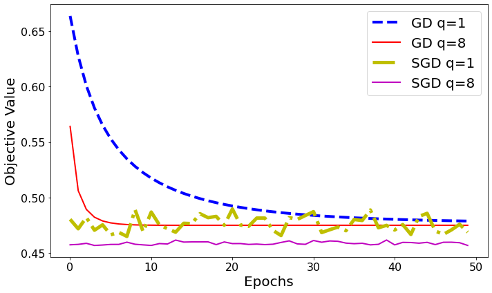

```python
import matplotlib.pyplot as plt
%matplotlib inline

fig = plt.figure(figsize=(10, 6))

epochs_gd1 = range(len(objvals_gd1))
epochs_gd8 = range(len(objvals_gd8))
epochs_sgd1 = range(len(objvals_sgd1))
epochs_sgd8 = range(len(objvals_sgd8))

line0, = plt.plot(epochs_gd1, objvals_gd1, '--b', LineWidth=4)
line1, = plt.plot(epochs_gd8, objvals_gd8, '-r', LineWidth=2)
line2, = plt.plot(epochs_sgd1, objvals_sgd1, '-.y', LineWidth=5)
line3, = plt.plot(epochs_sgd8, objvals_sgd8, '-m', LineWidth=2)
plt.xlabel('Epochs', FontSize=20)
plt.ylabel('Objective Value', FontSize=20)
plt.xticks(FontSize=16)
plt.yticks(FontSize=16)
plt.legend([line0, line1, line2, line3], ['GD q=1', 'GD q=8', 'SGD q=1', 'SGD q=8' ], fontsize=20)
plt.tight_layout()
plt.show()
fig.savefig('compare_gd_sgd.pdf', format='pdf', dpi=1200)
```